## Практична робота №4 . Схема Бернуллі.

# Мета : набути практичних навичок у розв’язанні типових задач в рамках схеми Бернуллі.

# 1 . (Задача 2020-го року про коронавірус). У Кременчуці станом на 03.04.20 було офіційно зареєстровано 4 хворих на коронавірус. Будемо реалістами і припустимо, що їх у сто разів більше, тобто 400. Маємо 250 000 жителів. Припускаємо, що жоден з вірусоносіїв не знаходиться у самоізоляції чи ізоляції і вільно пересувається містом. Таким чином імовірність випадкової зустрічі з вірусоносієм складає 𝑝 = 400 250000 =0,0016. Припустимо, що супермаркет у центрі міста відвідують щодня 10000 покупців. Яка ймовірність того, що серед них буде хоча б один хворий на коронавірус?

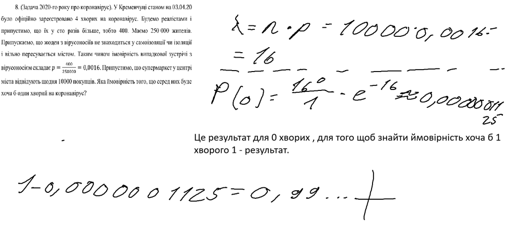

# 2 . Телефонна станція обслуговує 400 абонентів. Для кожного абонента ймовірність того, що протягом години він подзвонить на станцію, дорівнює 0,01. Знайдіть ймовірність наступних подій: а) протягом години 5 абонентів зателефонують на станцію; б) протягом години не більш 4 абонентів зателефонують на станцію; в) протягом години не менш 3 абонентів зателефонують на станцію.

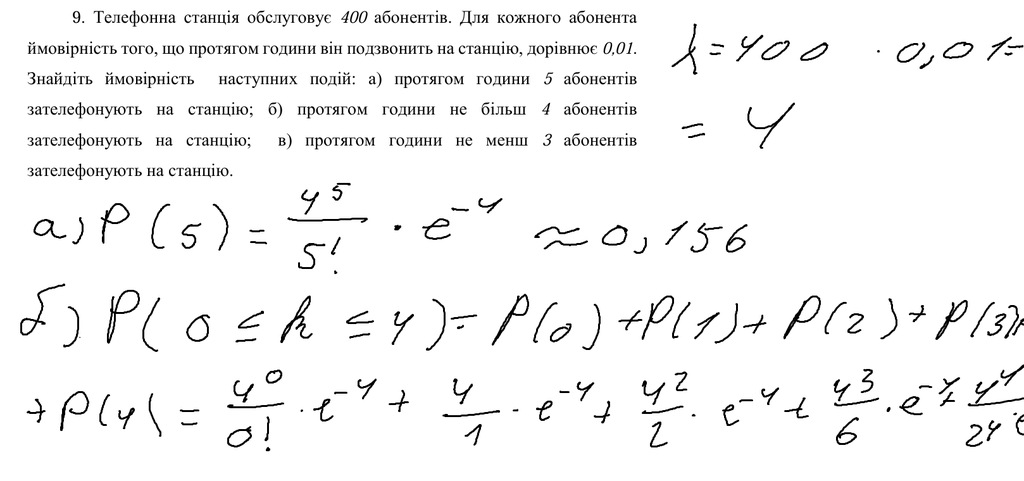

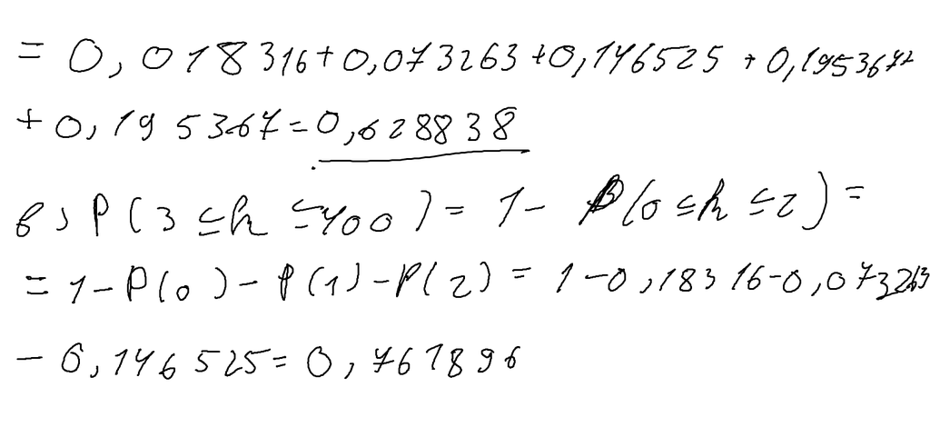

# 3 . Імовірність того, що деталь не є стандартною, дорівнює р=0,1. Знайти ймовірність того, що серед навмання відібраних 400 деталей відносна частота появи нестандартних деталей відхилиться від ймовірності р=0,1 за абсолютною величиною не більше ніж на 0,03.

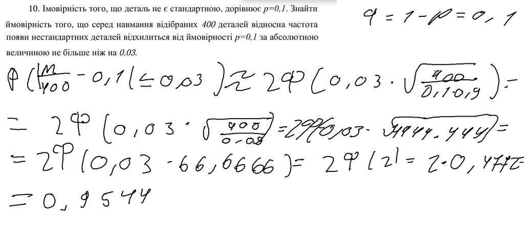

# 4 . У локальній комп’ютерній мережі підрозділу комерційного банку 20 персональних комп’ютерів. Кожен з клієнтів може протягом хвилини незалежно один від одного здійснити запит до серверу головної бази даних банку з ймовірністю p=0.3, або не здійснити з ймовірністю 𝑞 = 1 − 𝑝. а) чому дорівнює найбільш ймовірна кількість запитів за годину? б) чому дорівнює ймовірність найбільш ймовірної кількості запитів за годину? в) чому дорівнює ймовірність того, що кількість запитів за годину буде від 3 до 7? г) чому дорівнює ймовірність того, що хоча б один з клієнтів здійснить запит?

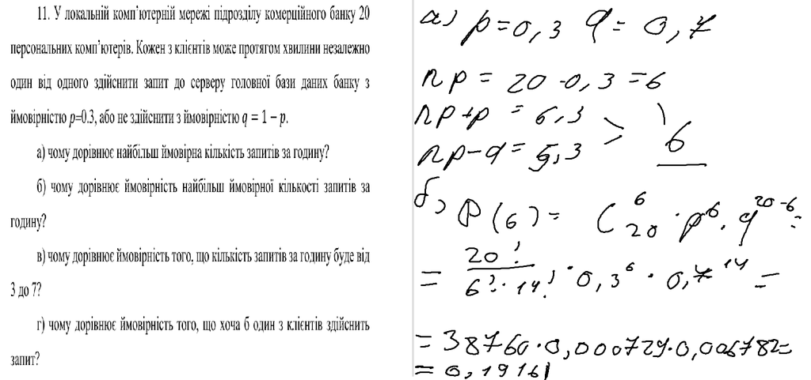

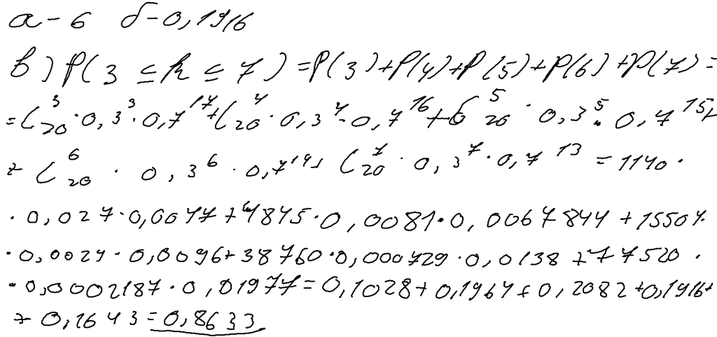

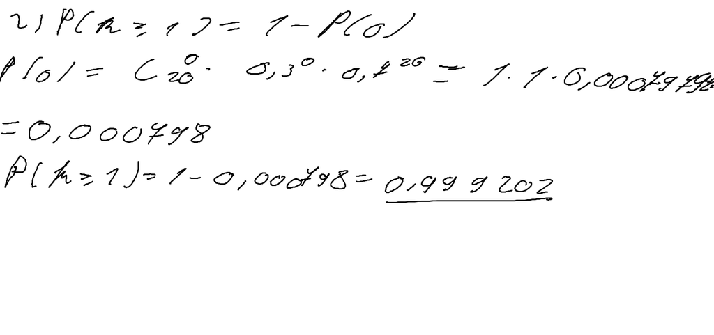

# 5 . У корпоративній мережі науково-виробничого об’єднання 1000 персональних комп’ютерів. Кожен з клієнтів може протягом хвилини незалежно один від одного здійснити запит до серверу головної бази даних з ймовірністю p=0,2, або не здійснити з ймовірністю𝑞 = 1 − 𝑝. а) чому дорівнює найбільш ймовірна кількість запитів за годину? б) чому дорівнює ймовірність найбільш ймовірної кількості запитів за годину? в) чому дорівнює ймовірність того, що кількість запитів за годину буде від 500 до 1000? г) чому дорівнює ймовірність того, що хоча б один з клієнтів здійснить запит?

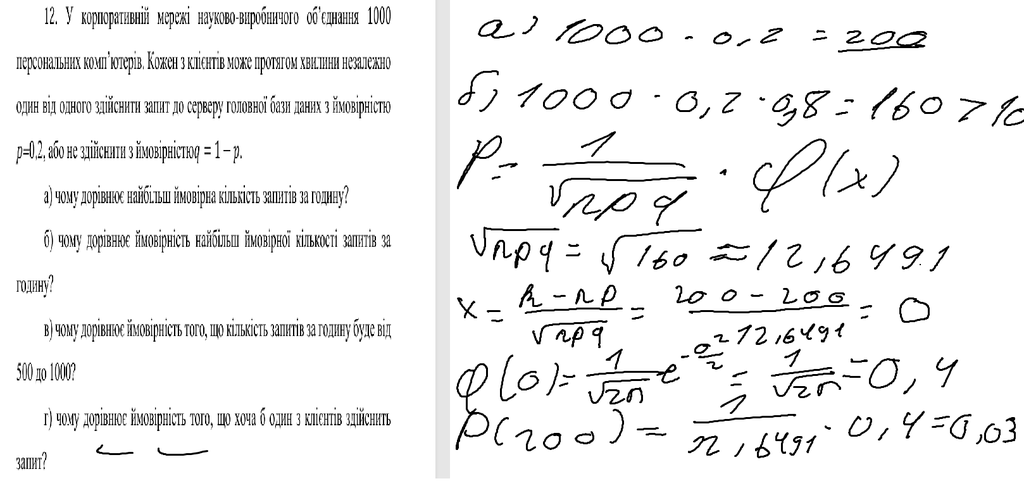

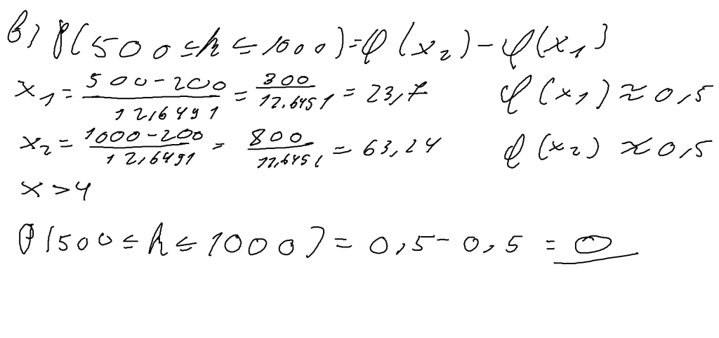

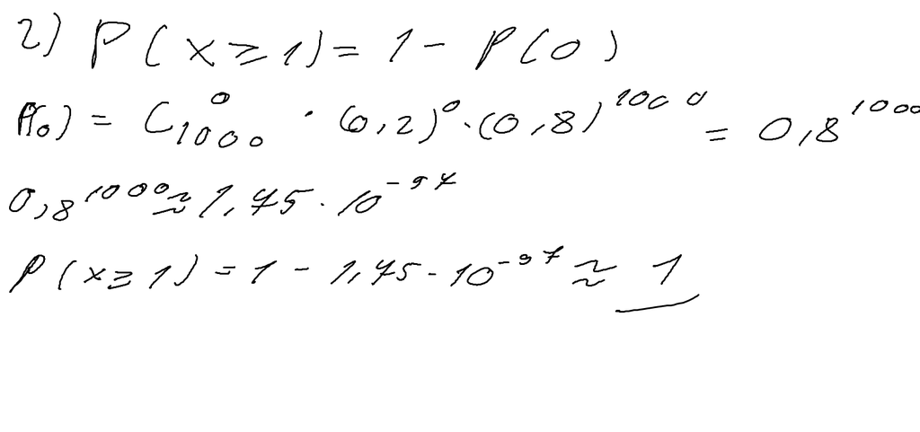

# 6 . Контрольні питання.

- Дати визначення схеми випробувань Бернуллі - це послідовність незалежних і повторюваних випадкових експериментів , кожен з яких має лише два взаємовиключних результати.
- Які властивості має випадковий експеримент за схемою Бернуллі? - фіксована кількість випробувань , два можливих взаємовиключних результата , незалежність випробувань , стала ймовірність.
- Що загального і в чому відмінність схеми випробувань Бернуллі від схеми випробувань, що описується гіпергеометричним розподілом? - Загальне : Два можливих результати , фіксована кількість випробувань.Відмінне - Спосіб відбору (Бернулі - з поверненням , Розподіл - без повернення) , у Бернулі незалежні випробуваня , а у розподілу залежні , у Бернулі стала ймовірність , а у розподілу змінна.
- Як визначається ймовірність отримати 𝑘 успіхів у 𝑛 незалежних випробуваннях за схемою Бернуллі? - по формулі (C з n по k * p^k * q^n-k).
- Навести приклади випадкових експериментів, які можна моделювати за допомогою схеми Бернуллі? - Можна привести підкидання монети або грального кубика також контроль якості виробництва , або опитування.

# 7 . Висновок

На практичному занятті ми набули практичних навичок у розв’язанні типових задач в рамках схеми Бернуллі.